# Ejemplo de uso del paquete `eph`

Germán Rosati

Diego Koslowski

Pablo Tiscornia

Guido Weksler

Natsumi Shokida

2019-11-11

El paquete `eph` tiene como objetivo facilitar el trabajo de les usuaries que trabajen con los microdatos de la Encuesta Permanente de Hogares. Este tutorial busca ejemplificar un pipeline de trabajo más o menos típico para mostrar el uso de las funciones del paquete.

## Instalación

Para instalar la versión estable del paquete usar:

```r
install.packages('eph')
```

Para la versión en desarrollo:

```r
# install.packages('devtools') si no tiene instalado devtools

devtools::install_github("holatam/eph")
```

## Ejemplo de flujo de trabajo

### Descarga de datos: `get_microdata()`

```r
library(eph)
library(tidyverse)
```

```r
ind_3_18 <- get_microdata(year=2018, trimester=2, type='individual')
```

Puede verse que la función requiere tres argumentos básicos:

- `year`: entero con el año de la encuesta que se desea descargar
- `trimester`: entero con el trimestre (este argumento es válido para la EPH continua, 2004-actualidad)
- `type`: character `"individual"`, para descargar la base de invidividuos y `"hogar"`, para la de hogar.

```r
ind_2_02 <- get_microdata(year=2001, wave=2, type='individual')
```

### Etiquetado: `organize_labels()`

Es posible etiquetar de forma automática el dataset llamando a la función `organize_labels()`:

```r
ind_3_18 <- organize_labels(df=ind_3_18, type='individual')
```

La función toma dos argumentos:

- `df`: el data.frame que se quiere etiquetar, debe ser producto de `get_microdata()`
- `type`: string; cuál es el tipo de datatset que se quiere etiquetar, `"individual"` o `"hogar"`

Descarguemos y etiquetemos la base de hogares del 3 trimestre de 2018. Podemos hacer uso de los `%>%` pipes de `magritte`:

```r
hog_3_18 <- get_microdata(year=2018, trimester=3, type='hogar') %>%
              organize_labels(., type='hogar')
```

### Tabulados ponderados: `calculate_tabulates()`

Uno de los problemas habituales en el trabajo con la EPH es la dificultad de los diferentes softwares comerciales para la construcción de tablas de contigencia y/o distribuciones de frecuencia ponderadas. El paquete lo resuelve mediante la función `calculate_tabulates()`:

```r
calculate_tabulates(base=ind_3_18, x='ESTADO', y='CH04', weights = 'PONDIH',
                    add.totals='row', add.percentage='col')
```

```
#>                                                                   ESTADO/CH04
#>  Entrevista individual no realizada (no respuesta al cuestionario individual)
#>                                                                       Ocupado
#>                                                                    Desocupado
#>                                                                      Inactivo
#>                                                            Menor de 10 anios.
#>                                                                         Total
#>   Varon  Mujer
#>    0.0%   0.0%
#>   49.0%  35.4%
#>    4.7%   4.3%
#>   30.3%  46.7%
#>   16.0%  13.6%
#>  100.0% 100.0%
```

Los argumentos principales de la función son:

- `base`: un data.frame proveniente de `get_microdata()`
- `x`: string con el nombre de la variable a tabular
- `y`: otro string (opcional) con el nombre de una segunda variable, para una tabla de doble entrada. Tiene que ser de igual largo que `x`
- `weights`: string con el nombre de la variable que contiene los pesos
- `add.totals`: agrega valores por `row`, `col` o `both`
- `add.percentage`: calcula porcentajes por `row`, `col` o `both`

Así, si quisiéramos la misma tabla sin ponderar:

```r
calculate_tabulates(base=ind_3_18, x='ESTADO', y='CH04',
                    add.totals='row', add.percentage='col')
```

```
#>                                                                   ESTADO/CH04
#>  Entrevista individual no realizada (no respuesta al cuestionario individual)
#>                                                                       Ocupado
#>                                                                    Desocupado
#>                                                                      Inactivo
#>                                                            Menor de 10 anios.
#>                                                                         Total
#>   Varon  Mujer
#>    0.1%   0.1%
#>   48.5%  34.0%
#>    3.6%   3.3%
#>   32.0%  48.8%
#>   15.9%  13.8%
#>  100.0% 100.0%
```

### Armando pools de datos: `organize_panels()`

Otra práctica común y necesaria en el trabajo con microdatos de la EPH es la generación de paneles de datos, es decir, el seguimiento de los registros a lo largo de las diferentes bases de la encuesta. Esto puede generarse en `eph` con la función `organize_panels()`

```r
bases <- list(i_2018_1=get_microdata(year=2018, trimester=1, type='individual'),
              i_2018_2=get_microdata(year=2018, trimester=2, type='individual'),
              i_2018_3=get_microdata(year=2018, trimester=3, type='individual'),
              i_2018_4=get_microdata(year=2018, trimester=4, type='individual')
)
```

```r
pool <- organize_panels(bases=bases, variables=c('ESTADO'),
                        window='trimestral')












pool
```

```
#> # A tibble: 75,308 x 17
#>    CODUSU NRO_HOGAR COMPONENTE  ANO4 TRIMESTRE  CH04  CH06 ESTADO Trimestre
#>    <chr>      <int>      <int> <int>     <int> <int> <int>  <int> <chr>
#>  1 TQRMN…         1          1  2018         1     2    67      3 2018_1
#>  2 TQRMN…         1          2  2018         1     1    81      1 2018_1
#>  3 TQRMN…         1          3  2018         1     2    22      2 2018_1
#>  4 TQRMN…         1          1  2018         1     1    62      1 2018_1
#>  5 TQRMN…         1          1  2018         1     1    83      3 2018_1
#>  6 TQRMN…         1          2  2018         1     2    79      3 2018_1
#>  7 TQRMN…         1          1  2018         1     2    79      3 2018_1
#>  8 TQRMN…         1          1  2018         1     1    38      1 2018_1
#>  9 TQRMN…         1          2  2018         1     2    33      1 2018_1
#> 10 TQRMN…         1          1  2018         1     1    64      1 2018_1
#> # … with 75,298 more rows, and 8 more variables: Id_Trimestre <dbl>,
#> #   ANO4_t1 <int>, TRIMESTRE_t1 <int>, CH04_t1 <int>, CH06_t1 <int>,
#> #   ESTADO_t1 <int>, Trimestre_t1 <chr>, consistencia <lgl>
```

$SO_{t} = \frac{\sum_{i=1}^n w_{i}TCP_{i}}{\sum_{i=1}^n w_{i}OCUP_{i}}$

```r
years <- 2011:2018
trims <- 1:4

indicator<-matrix(nrow=length(years) * length(trims), ncol=3)
i<-0
for (y in years){
        for (t in trims){
                i<-i+1
                d<-get_microdata(year=y, trimester = t) %>%
                  organize_labels(.)

                indicator[i,1]<-y
                indicator[i,2]<-t

                if (nrow(d) == 0){
                  indicator[i,3]<-NA
                }

                if (y==2007 & (t ==2 | t == 4)) {
                  indicator[i,3]<-sum(d[d$cat_ocup==2,]$pondera, na.rm=TRUE) /sum(d[d$estado==1,]$pondera, na.rm=TRUE)
                }

                else {
                indicator[i,3]<-sum(d[d$CAT_OCUP==2,]$PONDERA, na.rm=TRUE) /sum(d[d$ESTADO==1,]$PONDERA, na.rm=TRUE)
                }
      }
}
```

[output not shown]

[output cut: 194 more lines]

[output not shown]

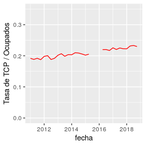

```r
indicator<-as.data.frame(indicator)
colnames(indicator)<-c('year', 'trim', 'ind')

indicator <- indicator %>%
  mutate(fecha = lubridate::parse_date_time(paste(indicator$year, indicator$trim, sep='-'), "%y%q"))


ggplot(data=indicator) +
        geom_line(aes(x=fecha,y=ind), color='red') +
        scale_y_continuous(limits=c(0,0.35)) +
        labs(y='Tasa de TCP / Ocupados')
```

### La yapa: cálculo de pobreza:

Un objetivo del paquete `eph`, es lograr automatizar el cálculo de pobreza e indigencia del INDEC para las bases trimestrales[^1]. El gran problema es que no existe información publicada fuera de los informes de prensa en formato pdf sobre los valores de las canastas básicas y alimentarias.

No obstante, hemos desarrollado dos funciones que, de encontrarse disponibles dichos datos, podrían calcular de forma automática los valores de pobreza e indigencia. Mostraremos un ejemplo de juguete con dos datasets de la CABA y sus respectivos valores de canastas.

```r
bases <- dplyr::bind_rows(toybase_individual_2016_03,toybase_individual_2016_04)
```

Existen dos funciones núcleo:

```r
lineas <- get_poverty_lines()
lineas %>% head()
```

```
#> # A tibble: 6 x 4
#>   periodo               CBA   ICE   CBT
#>   <dttm>              <dbl> <dbl> <dbl>
#> 1 2016-04-01 00:00:00 1515.  2.42 3664.
#> 2 2016-05-01 00:00:00 1561.  2.45 3831.
#> 3 2016-06-01 00:00:00 1614.  2.44 3943.
#> 4 2016-07-01 00:00:00 1666.  2.42 4034.
#> 5 2016-08-01 00:00:00 1675.  2.41 4042.
#> 6 2016-09-01 00:00:00 1711.  2.39 4090.
```

Esta función descarga los valores de las canastas alimentaria, básica (CBA y CBT) y la inversa del coeficiente de Engels… perdón, Engel (ICE) de [la serie provista por INDEC](https://www.indec.gob.ar/indec/web/Nivel4-Tema-4-43-149).

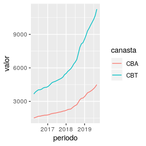

```r
lineas %>%
  select(-ICE) %>%
  gather(canasta, valor, -periodo) %>%
  ggplot() +
    geom_line(aes(x=periodo, y=valor, col=canasta))
```

La segunda función calcula la pertenencia a situaciones de pobreza e indigencia a nivel de los individuos siguiendo la metodología de línea:

```r
#calculate_poverty(bases, basket=lineas)
```

[^1]: El calculo oficial se realiza sobre bases semestrales no publicadas